# GEOG 6000 Lab 07 Cluster analysis and PCA

Author

Affiliation

Simon Brewer

University of Utah

Published

October 7, 2026

# Introduction

This lab is designed to cover the multivariate methods from the last two lectures, including cluster analysis and PCA. Before starting the lab, you will need to set up a new folder for your working directory. Go to your `geog6000` folder now and create a new folder for today’s class called `lab07`. The following files will be used in this lab, all available on Canvas:

- A dataset of Western North America climate: *wnaclim2.csv*
- A data set of the characteristics of cars: *cars.tab.csv*
- The US State dataset: *statedata.csv*
- Boston housing dataset *boston6k.csv*

You will need to download these files from Canvas, and move them from your `Downloads` folder to the `data` folder that you made previously.

Now start RStudio and change the working directory to `lab07`. As a reminder, you can do this by going to the [Session] menu in RStudio, then [Change working directory]. This will open a file browser that you can use to browse through your computer and find the folder.

You will also need to install the following add-on packages **fields**, **maps** and **fpc**.

**With all the examples given, it is important to not just type in the code, but to try changing the parameters and re-running the functions multiple times to get an idea of their effect.** Help on the parameters can be obtained by typing `help(functionname)` or `?functionname`.

# Distance measures and cluster analysis

## Distance measures

We start by loading the cars dataset. This has six variables relating to engine size and performance from 38 cars from the late 1970’s.

```r
cars <- read.csv("./data/cars.tab.csv")
head(cars)
```

In order to use the cars data frame in cluster analysis, we need to do two things: first we remove the first two columns, which contain labels, then we scale the remaining data to make the variance of the different variables comparable. To do this, we use the `scale()` function, which subtracts the mean from each column and then divides by the standard deviation of that column. This is known as standardizing to zero mean and unit variance, and converts each observation into a number of standard deviations away from the mean. Note that the object returned by `scale()` has *attributes* which contain both the mean and s.d. used in standardizing the data.

```r
cars.use <- cars[, -c(1, 2)]
cars.use <- scale(cars.use)
```

To see the effect of this, make a histogram of the horsepower values on the original and standardized scale:

```r
par(mfrow = c(2,1))
hist(cars[, "Horsepower"], main = "Horsepower: original scale")
hist(cars.use[, "Horsepower"], main = "Horsepower: standardized scale")
par(mfrow = c(2, 1))
```

Use the `dist()` function to explore the multivariate distances between different cars. This returns the distance matrix for the first four cars, using two different methods:

```r
dist(cars.use[1:4, ], method = 'euclidean')
dist(cars.use[1:4, ], method = 'manhattan')
```

Finally, create the full distance matrix for all cars for use in hierarchical clustering:

```r
cars.dist = dist(cars.use)
cars.dist
```

## Hierarchical clustering

We can now use this distance matrix to perform hierarchical clustering on the cars dataset. We use the `hclust()` function, which requires the distance matrix and the type of comparison to be used between clusters as the function proceeds. We use here Ward’s method, which uses the distances between the centroids of two clusters to assess their overall similarity. Once the `hclust()` function has run, we plot out the dendogram:

```r
cars.hclust <- hclust(cars.dist, method = 'ward.D2')
plot(cars.hclust, labels = cars$Car, main = 'Default from hclust')
```

Each vertical line represents a group that was identified when objects were joined together into clusters. The observations in that group are represented by the branches of the dendogram that spread out below the line. For example, if we look at a height of 6, and move across the x-axis at that height, we’ll cross two lines. That defines a two-cluster solution; by following the line down through all its branches, we can see the names of the cars that are included in these two clusters. The y-axis represents the similarity between observations when clusters were formed, small differences on the y-axis suggests that clusters are not particularly reliable. Big differences along the y-axis between the last merged cluster and the currently merged one, indicate that the clusters formed are probably doing a good job in showing us the structure of the data.

The `rect.hclust()` function allows us to visualize what the groups will look like if cut off the tree at either a specified height (parameter: `h`) or for a set number of groups (parameter: `k`). Note that this is an overlay and you will need to first plot the dendogram

```r
plot(cars.hclust, labels = cars$Car, main = 'Default from hclust')
rect.hclust(cars.hclust, k = 3)
```

The `cutree()` function allows us to cut off the tree at some point to provide a set of groups, again using either a set number of groups or height in the tree.

```r
groups.3 = cutree(cars.hclust, k = 3)
```

We can use these results to examine the characteristics of the clusters, for example, the number of cars in each cluster, or the cars that belong to cluster 1:

```r
table(groups.3)
cars$Car[groups.3 == 1]
```

As we have information about the country of manufacture, we can also look to see if there is a national bias in any of the groups:

```r
table(groups.3, cars$Country)
```

Finally, we can characterize the clusters using the original information on the cars. The `aggregate()` function allows us to calculate the median MPG, weight, etc for each cluster and helps explain why the clusters are formed. Note that we use the original data frame for this, rather than the scaled data frame, in order to have more interpretable results.

```r
aggregate(cars[, -c(1, 2)], list(groups.3), median)
```

## $k$-means clustering

We will now look at $k$-means clustering using a geographical dataset of climate in western North America. We will use the **maps** package to help map out the results and plot a simple coastline. This will need to be installed and loaded prior to use. As a reminder:

- Install packages using either the `install.packages()` function, or the [Install] button from the Packages tab. Packages only need to be installed once
- Load packages using the `library()` function. Packages need to be reloaded each time you restart R

```r
library(maps)
```

We now do the following: load the climate dataset, create a new variable with the site coordinates and define $k$, the number of groups.

```r
wnaclim <- read.csv("./data/wnaclim2.csv")
wnaloc <- cbind(wnaclim$Longitude, wnaclim$Latitude)
ngrp <- 6
```

Make a simple location plot of the sites:

```r
plot(wnaloc)
map(add=TRUE)
```

Prior to any clustering, we extract the variables we want to use (12 monthly values of temperature and precipitation), then scale these to remove any bias due to the difference in magnitudes of the variables:

```r
wnaclim <- wnaclim[, seq(3,26)]
wnaclim.s <- scale(wnaclim)
```

We will now carry out a $k$-means classification of the WNA climate dataset. We use the scaled dataset directly, rather than the distance matrix, and run the algorithm several times from different random starts to try and get the best clustering solution, we also set the number of iterations. We use the `table()` function to get the number of observations per cluster:

```r
wna.kmeans <- kmeans(wnaclim.s, ngrp, nstart = 50, iter.max = 20)
table(wna.kmeans$cluster)
```

```
  1   2   3   4   5   6
712  59 275 263 545 563
```

Plot the distribution of $k$-means clusters in space. We first build a color palette for the number of clusters. There are several built in palettes in R, `rainbow` is one. This produces a set of $n$ colors from this palette, which are evenly spaced along the complete palette. When plotting, we use the vector of cluster assignments as indices to assign the correct color to each observation:

```r
mycol <- rainbow(ngrp)
plot(wnaloc, xlab = '', ylab = '', pch = 16, col = mycol[wna.kmeans$cluster])
map(add = TRUE)
```

### $k$-means prototypes

In $k$-means cluster analysis, the prototype refers to the centroid of each cluster. Each prototype has a value for all the variables used in clusters (for each variable this is the mean of all variables in the set). These values are output as part of the `kmeans()` function, and are stored as `centers`:

```r
wna.kmeans$centers
```

However, these are the scaled values, and before plotting these, we would need to convert them back to their original scale. An easier way is to use the `aagregate()` function as in the previous example. Here we get aggregate values for all monthly precipitation and temperature by cluster, then split this into two sets, one for temperature and one for precipitation:

```r
wna.centers <- aggregate(wnaclim, list(wna.kmeans$cluster), mean)
wna.centers
temp.centers <- wna.centers[ , 2:13]
ppt.centers <- wna.centers[ , 14:25]
```

We can use these to make some simple climatology plots for the clusters we obtained. For this, we can use the `matplot()` function. This is a helper function, that plots all the columns of a matrix as individual series, and saves having to repeatedly add lines to a plot. As the prototypes are ordered by row, we simply transpose them to plot each cluster temperature over the 12 months of the year:

```r
matplot(t(temp.centers), type = 'l', lwd = 2, lty = 2, col = mycol,
        xlab = "Month", ylab = "Temp C")
matplot(t(ppt.centers), type = 'l', lwd = 2, lty = 2, col = mycol,
        xlab = "Month", ylab = "PPT mm")
```

## Testing clustering solutions

There are several tools which can be used to help in examining the output of cluster analysis, which are generally available in add-on packages. Here, we will use the **cluster** package for the silhouette index, and the **fpc** package to calculate the Calinski-Harabasz index. Both of these packages have a lot of extended functionality for cluster analysis and are worth investigating if you plan to do clustering with your own data. The **cluster** package is installed (but not loaded) with base R; you will have to install the **fpc** package.

Start by loading these packages:

```r
library(cluster)
library(fpc)
```

We’ll first look at the values of both of these indices for the $k$-means analysis that we have just run.

### Calinski-Harabasz

This is calculated use the `calinhara()` function from **fpc**. The function needs the dataset that was used in the clustering and the vector that contains the cluster membership for each observation.

```r
calinhara(wnaclim.s, wna.kmeans$cluster)
```

Which gives us a value of 1731.52 (your value will likely be different due to the random nature of $k$-means). As this is based on calculations of sum-of-squares, this value on its own does not mean much. But as we will see below, we can use this to compare different clusterings to see which works the best.

### Silhouette index

This is calculated use the `silhouette()` function from **cluster**. This function requires a vector that contains the cluster membership for each observation, and a dissimilarity matrix, which we can calculate using `dist()`.

```r
sil.out <- silhouette(wna.kmeans$cluster, dist(wnaclim.s))
sil.out[1:4, ]
```

This produces a $n \times 3$ data frame that contains for each row: the assigned cluster, the next nearest cluster and the silhouette value for that observation. Remember that this index varies between -1 and 1, with the following interpretation:

- Close to 1: observation is clustered
- Close to 0: observation is on the border between two clusters
- Close to -1: observation is poorly clustered

We can then easily calculate the average silhouette index for this set of clusters as:

```r
mean(sil.out[, 3])
```

```
[1] 0.3588962
```

Or the average index per cluster as:

```r
tapply(sil.out[, 3], sil.out[, 1], mean)
```

Finally, we can make a silhouette plot, which plots the index for each observation, sorted by cluster and by index value. This is an easy way to inspect the cluster output for possible problems. If we specify a set of $k$ colors, then each cluster will be colored differently (we can use the colors that were generated for the map above).

```r
plot(sil.out, col = mycol, main = "WNA Climate Silhouette Plot")
```

[This may not plot clearly to the screen. If you are having difficulty in seeing the silhouette plot, try plotting to a PNG or PDF file instead.]

### Testing different cluster numbers

```r
ch.out <- rep(NA,20) ## Calinksi index
sil.out <- rep(NA,20) ## Silhouette index
for (i in 2:20) {
  wna.kmeans <- kmeans(wnaclim.s, centers = i, nstart = 50)
  ch.out[i] <- calinhara(wnaclim.s, wna.kmeans$cluster)
  tmp <- silhouette(wna.kmeans$cluster, dist(wnaclim.s))
  sil.out[i] <- mean(tmp[,3])
}
```

We can now plot the changes in the Calinski-Harabasz index as the number of groups increases:

```r
plot(1:20,ch.out, type = 'b', lwd = 2,
     xlab = "N Groups", ylab = "C", main = "Calinski-Harabasz index")
```

Or the average silhouette index:

```r
plot(1:20,sil.out, type = 'b', lwd = 2,
     xlab = "N Groups", ylab = "C", main = "Average silhouette index")
```

Both of these show fairly clear maximum values at around 3 groups, suggesting the $k=3$ maybe the best set of clusters for this data. But remember: **these are tools to help you decide how many clusters are needed, and your own judgment is as important**. For example, you may need a greater number of groups to understand the patterns in the data, or a suggested cluster may not have a useful explanation.

# Principle Component Analysis

Load the dataset of US State characteristics, remove the first column (state names) and add it back as row names (this will help in the output):

```r
state <- read.csv("./data/statedata.csv")
state2 <- state[, -1]
rownames(state2) <- state[, 1]
```

R has two functions for PCA, `princomp()`, which uses eigenanalysis to decompose the data matrix and `prcomp()`, which uses singular value decomposition (SVD). While these are generally comparable, `prcomp()` is recommended for numerical accuracy. As the original data have a variety of units, it is necessary to account for this by using the correlation matrix (in `princomp()`) or by scaling the data to zero mean and unit standard deviation (in `prcomp()`).

```r
state.pca <- prcomp(state2, scale = TRUE)
```

Use the `summary()` function to examine the eigenvalues of the PCA results. These are expressed in standard deviation units (of the original data), and are used to calculate the proportion of variance explained by each principal component. The first component will explain the greatest amount of variance, this declines with subsequent components. Note that a) there are as many components as original variables ($p$) and b) that the full set of components explain 100% of the total variance.

```r
summary(state.pca)
```

Note that the variance values are given in standard deviation units here. To back convert these into the amount variance on each axes, we need to square the values given in the summary:

```r
state.pca$sdev^2
```

The amount of variance explained can also be visualized using a screeplot:

```r
screeplot(state.pca)
```

The `prcomp()` function returns an object containing various output from the principal component analysis. The variable `rotation` in this object gives the variable loadings, the association between the original variables and the new components. High values indicate greater associations — note that the direction of association can be positive or negative:

```r
state.pca$rotation
```

The loadings reflect both the strength and the direction of association (the direction of the eigenvectors), so life expectancy increases toward negative values of component 1, and area increases with positive values of component 2. We can use this to try and assign some meaning to the axes: e.g. axis 1 represents a social-economic gradient, and axis 2 is related the physical geography of the state.

The site scores are contained in the variable `x`, giving the association between each observation and the new components. As before, high values indicate greater associations — note that the direction of association can be positive or negative. This will visualize the scores for the first four components:

```r
state.pca$x[, 1:4]
```

With this information, we can extract the scores for the states on any given component. By sorting this, we can obtain a gradient of states from negative values (high life expectancy and high school graduation) to positive values (high illiteracy and murder):

```r
sort(state.pca$x[, 1])
```

The results of PCA and other ordinations are traditionally visualized with a biplot. This is a two-dimensional plot where the two axes are selected principal components. The biplot includes the position of the observations, based on their scores and vectors representing the original variables.

```r
biplot(state.pca, xlim = c(-0.4, 0.6))
```

By default, the `biplot()` function plots the first two components. The previous output suggests that the third and fourth components also explain part of the variance. We can plot these out by using the `choices` parameter, e.g. for to plot axes 1 and 3:

```r
biplot(state.pca, choices = c(1, 3))
```

This shows a new arrangement of the data. The third axis is split between area and population, and can be interpreted as representing population density.

# Exercises

1. The file *boston6k.csv* contains information on house prices in Boston by census tract, as well as various socio-economic and environmental factors. Use this to cluster the tracts by these factors (NOT by price), then examine the characteristics of the clusters, whether they show a difference in house price and if there is any spatial structure to the clusters. Use only the following variables in the cluster analysis: CRIM, ZN, INDUS, CHAS, NOX, RM, AGE, DIS, RAD, TAX, PTRATIO, B, LSTAT (see the file description for explanations of these). You will need to scale the data as the variables are in a wide range of units.
   - Start by running $k$-means cluster analysis on the data from 2 to 20 clusters, using the approach outlined above. You should calculate *either* the silhouette index or the Calinski-Harabasz index for each set of clusters. Provide a plot of the index values, and identify the number of clusters ($k$) that gives the best solution
   - In your opinion, is this the best solution, or would more or less clusters be useful?
   - Re-run `kmeans()` using your chosen number for $k$
   - Using the `aggregate()` function, provide a table showing the median the variables used in clustering. In 1-2 sentences, describe the characteristics of the clusters
   - Report the mean corrected house value per cluster
   - Use `anova()` to test whether the values are significantly different between clusters. You will need the vector of house prices/values and the vector of clusters from `kmeans()`. Give the $F$-statistic and the $p$-value
2. The file *wnaclim2.csv* contains a set of climatic variables for sites distributed across western North America. Use principal component analysis to explore the spatial distribution of climate. This will require you to install the add-on package **fields** for plotting.
   - Read in the file and perform principal component analysis using the monthly temperature and precipitation variables (these are the same as you used in the cluster analysis in the lab). . Use the SVD approach with the function `prcomp()`. Note that you will have to use to scale the data in the PCA to avoid any bias from the difference in magnitude of the variables in the dataset (use the `scale=TRUE` parameter). Make a biplot of this ordination (`biplot()`) and a scree-plot showing the variance explained by the components (`screeplot()`).
   - Give the total variance from the second PCA. Calculate the total percentage of variance explained by axes 1 and 2 (use `summary()`)
   - Examine the ‘loadings’ of the variables on the first two axes (`wnaclim.pca$rotation`). Name two variables that are highly associated (high positive or negative values) with axis 1 and two that are highly associated with axis 2, and give their scores.
   - Produce a map of the sites scores on axis 1, using the `quilt.plot()` function from the **fields** package (code to do this is given with the file description below). With reference to the association between the variables and axis 1 (previous question), give a short description of the map (e.g. where do you find negative or positive values and what variables are these associated with?). Does this make sense in terms of what you know about the geography and climate of North America?
   - Finally, produce a map of the sites scores on the second axis and give a short description of the spatial pattern in terms of the associated variables

# Files used in lab

## US State data set: *statedata.csv*

| Column header | Variable |
| --- | --- |
| State | State abbreviation |
| Population | Population estimate (1975) |
| Income | Per capita income (1974) |
| Illiteracy | Illiteracy (%age, 1970) |
| Life.Exp | Life expectancy in years (1969-71) |
| Murder | Murder rate per 100K population (1976) |
| HS.Grad | Percent high-school graduates (1970) |
| Frost | Number of days < 32F in largest city (1931-60) |
| Area | Area of state (square miles) |

## Car data set: *car.tab.csv*

| Column header | Variable |
| --- | --- |
| Country | Country of manufacture |
| Car | Car model |
| MPG | Miles per gallon |
| Weight | Weight |
| Drive_Ratio | Gear ratio |
| Horsepower | Horsepower |
| Displacement | Engine displacement |
| Cylinders | Number of cylinders |

## Boston housing dataset: *boston6k.csv*

| Column header | Variable |
| --- | --- |
| ID | Sequential ID |
| TOWN | Town names |
| TOWNNO | Town ID |
| TRACT | Tract ID numbers |
| LON | Longitude in decimal degrees |
| LAT | Latitude in decimal degrees |
| MEDV | Median values of owner-occupied |
|  | housing (USD 1000) |
| CMEDV | Corrected median values of owner-occupied |
|  | housing (USD 1000) |
| CRIM | Per capita crime |
| ZN | Proportion of residential land zoned |
|  | for lots over 25000 sq. ft |
| INDUS | Proportions of non-retail business acres per town |
| CHAS | 1 if tract borders Charles River; 0 otherwise |
| NOX | Nitric oxides concentration (parts per 10 million) |
| RM | Average numbers of rooms per dwelling |
| AGE | Proportions of owner-occupied units built prior to 1940 |
| DIS | Weighted distances to five Boston employment centers |
| RAD | Index of accessibility to radial highways per town |
| TAX | Property-tax rate per USD 10,000 per town |
| PTRATIO | Pupil-teacher ratios per town |
| B | Proportion African-American |
| LSTAT | Percent lower status population |

## Western North America climate data: *WNAclimate.csv*

| Column header | Column header | Variable |
| --- | --- | --- |
| 1 | Longitude | Longitude |
| 2 | Latitude | Latitude |
| 3-14 | t* | Monthly temperature |
| 15-26 | p* | Monthly precipitation |
| 27 | tave | Average annual temperature |
| 28 | tmax | Maximum temperature |
| 29 | tmin | Minimum temperature |
| 30 | gdd0 | Growing degree days ($>0$ C) |
| 31 | gdd5 | Growing degree days ($>5$ C) |
| 32 | mtco | Temperature of the coldest month |
| 33 | mtwa | Temperature of the warmest month |
| 34 | annp | Annual precipitation |

## Code to map PCA scores

Note that this code requires the package **fields** to be installed and loaded. This includes two functions we can use to make a simple map: `quilt.plot()` which produces a color-scaled, gridded map from a set of point observations; and `world()` which adds a simple coastline. The object `wnaclim.pca` was made in a previous step using `prcomp()`.

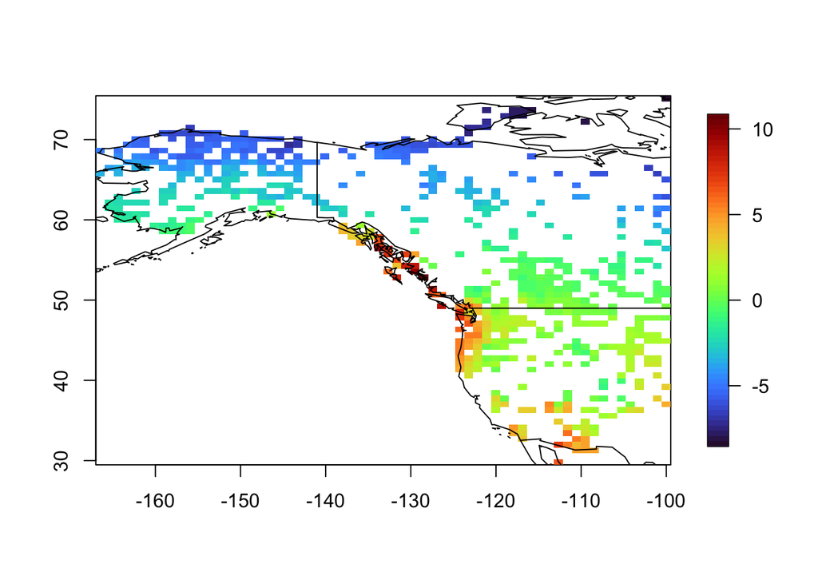

```r
wnaclim.pca.score <- wnaclim.pca$x[, 1]
quilt.plot(wnaclim$Longitude, wnaclim$Latitude, wnaclim.pca.score)
world(add = TRUE)
```